# Data mining final project

# By Jaouher Koussani

# Car Evaluation

## Plan

### 0.Introduction

### 1.Data Preprocessing

#### 1.1. Data Cleaning

#### 1.2. Data Engineering

### 2.Feature Selection

#### Filter Model

### 3.Data Preparation

#### A.Normalization

#### B.Splitting the data into training and test sets

### 4.Single Classifiers

#### 4.1.Decision trees

#### 4.2.K-nearest neighbors

### 5.Ensemble Classifiers

#### Bagging Classifier

## I.Introduction

The dataset used in this project is the car evaluation dataset, which we downloaded from [the UCI directory] https://archive.ics.uci.edu/ml/datasets/Car+Evaluation it is a dataframe with 6 features, 1 class variable and 1728 instances.

The objective of this project is to build and compare models which can predict if a car is acceptable or not, based on 6 features.

## Data Preprocessing

```python
import pandas as pd
import numpy as np
import seaborn as sns
from scipy.stats import chi2_contingency
from scipy.stats import f_oneway
#from sklearn.feature_extraction.text import Tfidvectorizer
from sklearn.naive_bayes import MultinomialNB
#from sklearn.pipeline import make_pipeline
import re
from sklearn.neighbors import KNeighborsClassifier
#!pip install
from matplotlib import pyplot as plt
from sklearn.preprocessing import LabelEncoder
from sklearn.model_selection import GridSearchCV
from sklearn.metrics import accuracy_score, classification_report
from sklearn.model_selection import cross_val_score
from sklearn.ensemble import BaggingClassifier
from sklearn.ensemble import AdaBoostClassifier
```

Let's load the dataframe and take a look at the first 5 observations

```python
data = pd.read_csv('car.csv', sep=',')
print(data.head())
```

```
  buying   main doors persons lug_boot safety acceptability
0  vhigh  vhigh     2       2    small    low         unacc
1  vhigh  vhigh     2       2    small    med         unacc
2  vhigh  vhigh     2       2    small   high         unacc
3  vhigh  vhigh     2       2      med    low         unacc
4  vhigh  vhigh     2       2      med    med         unacc
```

```python
print(data.shape)
```

```
(1728, 7)
```

Our dataframe consists of 1728 instances, 6 features and 1 class variable

```python
print(data.info())
```

```
<class 'pandas.core.frame.DataFrame'>
RangeIndex: 1728 entries, 0 to 1727
Data columns (total 7 columns):
 #   Column         Non-Null Count  Dtype
---  ------         --------------  -----
 0   buying         1728 non-null   object
 1   main           1728 non-null   object
 2   doors          1728 non-null   object
 3   persons        1728 non-null   object
 4   lug_boot       1728 non-null   object
 5   safety         1728 non-null   object
 6   acceptability  1728 non-null   object
dtypes: object(7)
memory usage: 94.6+ KB
None
```

**Buying**: Buying price  
**Main** : Maintenance price of the car  
**Doors** : Number of doors in the car  
**Persons**: Persons capacity in terms of persons to carry  
**lug_boot**: the size of luggage boot  
**safety**: estimated safety of the car

Here are the possible values for each column

```python
for i in data:
    print(i, data[i].unique())
```

```
buying ['vhigh' 'high' 'med' 'low']
main ['vhigh' 'high' 'med' 'low']
doors ['2' '3' '4' '5more']
persons ['2' '4' 'more']
lug_boot ['small' 'med' 'big']
safety ['low' 'med' 'high']
acceptability ['unacc' 'acc' 'vgood' 'good']
```

```python
data.describe()
```

|  | buying | main | doors | persons | lug_boot | safety | acceptability |
| --- | --- | --- | --- | --- | --- | --- | --- |
| count | 1728 | 1728 | 1728 | 1728 | 1728 | 1728 | 1728 |
| unique | 4 | 4 | 4 | 3 | 3 | 3 | 4 |
| top | high | high | 5more | 4 | small | high | unacc |
| freq | 432 | 432 | 432 | 576 | 576 | 576 | 1210 |

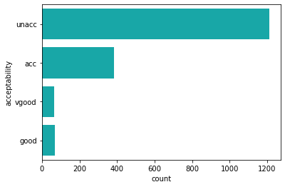

```python
sns.countplot(y="acceptability", data = data , color="c")
```

### Data Cleaning

#### Missing values

```python
print(data.isnull().sum())
```

```
buying           0
main             0
doors            0
persons          0
lug_boot         0
safety           0
acceptability    0
dtype: int64
```

### Data Engineering

```python
data['Y'] = data['acceptability']
```

```python
data['Y'] = data['Y'].map({'unacc':'Yes', 'good':'No', 'acc':'No', 'vgood':'No'})
```

```python
print(data.Y.unique())
```

```
['Yes' 'No']
```

```python
## Decision Trees
```

The decision trees algorithm will do a wrapper model for feature selection, that's why we will build our tree using all features as input but we will specify that the tree has a maximum depth of 3, which means that it will choose the top 3 features

## Feature Selection

## Filter model

We will try to find the best features of our dataset using a minimum redundance, maximum relevance approach. For this purpose we will test if there's a significant correlation between each independant variable (X) and the dependant variable (Y). Then we will check if there is a mutual information between independant variables. For all of these tests we will use the chi square test since all of our variables are categorical

```python
contingency = pd.crosstab(data['buying'], data['Y'])
chi2, p, dof, expected = chi2_contingency(contingency)
print(p)
```

```
1.7095876176351842e-16
```

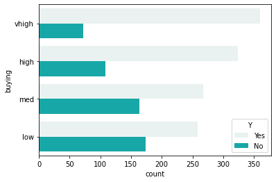

```python
sns.countplot(y="buying", data = data , color="c", hue="Y")
```

```python
contingency = pd.crosstab(data['main'], data['Y'])
chi2, p, dof, expected = chi2_contingency(contingency)
print(p)
```

```
7.546204594041803e-14
```

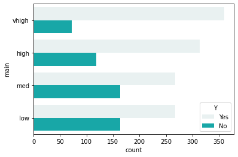

```python
sns.countplot(y="main", data = data , color="c", hue="Y")
```

```python
#data['doors'] = data['doors'].map({2:'2', 3:'3', 4:'4', 5:'5more'})
contingency = pd.crosstab(data['doors'], data['Y'])
chi2, p, dof, expected = chi2_contingency(contingency)
print(p)
```

```
0.035258836859245066
```

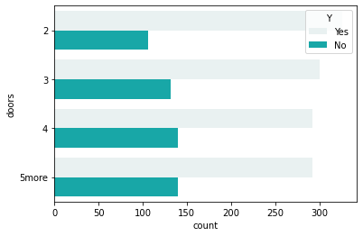

```python
sns.countplot(y="doors", data = data , color="c", hue="Y")
```

```python
contingency = pd.crosstab(data['persons'], data['Y'])
chi2, p, dof, expected = chi2_contingency(contingency)
print(p)
```

```
3.910942687357585e-81
```

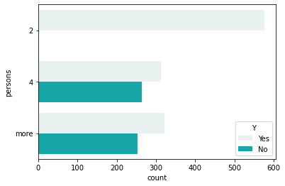

```python
sns.countplot(y="persons", data = data , color="c", hue="Y")
```

```python
contingency = pd.crosstab(data['lug_boot'], data['Y'])
chi2, p, dof, expected = chi2_contingency(contingency)
print(p)
```

```
4.129051779512971e-07
```

```python
contingency = pd.crosstab(data['safety'], data['Y'])
chi2, p, dof, expected = chi2_contingency(contingency)
print(p)
```

```
8.60814372627573e-87
```

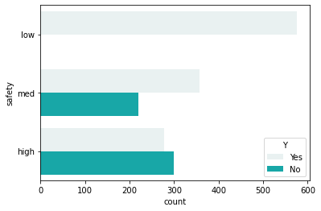

```python
sns.countplot(y="safety", data = data , color="c", hue="Y")
```

```python
contingency = pd.crosstab(data['safety'], data['buying'])
chi2, p, dof, expected = chi2_contingency(contingency)
print(p)
print(contingency)
```

```
1.0
buying  high  low  med  vhigh
safety
high     144  144  144    144
low      144  144  144    144
med      144  144  144    144
```

```python
contingency = pd.crosstab(data['safety'], data['lug_boot'])
chi2, p, dof, expected = chi2_contingency(contingency)
print(p)
print(contingency)
```

```
1.0
lug_boot  big  med  small
safety
high      192  192    192
low       192  192    192
med       192  192    192
```

```python
contingency = pd.crosstab(data['safety'], data['main'])
chi2, p, dof, expected = chi2_contingency(contingency)
print(p)
print(contingency)
```

```
1.0
main    high  low  med  vhigh
safety
high     144  144  144    144
low      144  144  144    144
med      144  144  144    144
```

```python
contingency = pd.crosstab(data['safety'], data['persons'])
chi2, p, dof, expected = chi2_contingency(contingency)
print(p)
print(contingency)
```

```
1.0
persons    2    4  more
safety
high     192  192   192
low      192  192   192
med      192  192   192
```

```python
contingency = pd.crosstab(data['main'], data['buying'])
chi2, p, dof, expected = chi2_contingency(contingency)
print(p)
print(contingency)
```

```
1.0
buying  high  low  med  vhigh
main
high     108  108  108    108
low      108  108  108    108
med      108  108  108    108
vhigh    108  108  108    108
```

```python
contingency = pd.crosstab(data['main'], data['persons'])
chi2, p, dof, expected = chi2_contingency(contingency)
print(p)
print(contingency)
```

```
1.0
persons    2    4  more
main
high     144  144   144
low      144  144   144
med      144  144   144
vhigh    144  144   144
```

```python
contingency = pd.crosstab(data['main'], data['lug_boot'])
chi2, p, dof, expected = chi2_contingency(contingency)
print(p)
print(contingency)
```

```
1.0
lug_boot  big  med  small
main
high      144  144    144
low       144  144    144
med       144  144    144
vhigh     144  144    144
```

```python
contingency = pd.crosstab(data['buying'], data['persons'])
chi2, p, dof, expected = chi2_contingency(contingency)
print(p)
print(contingency)
```

```
1.0
persons    2    4  more
buying
high     144  144   144
low      144  144   144
med      144  144   144
vhigh    144  144   144
```

```python
contingency = pd.crosstab(data['buying'], data['lug_boot'])
chi2, p, dof, expected = chi2_contingency(contingency)
print(p)
print(contingency)
```

```
1.0
lug_boot  big  med  small
buying
high      144  144    144
low       144  144    144
med       144  144    144
vhigh     144  144    144
```

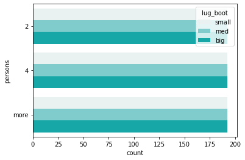

```python
sns.countplot(y="persons", data = data , color="c", hue="lug_boot")
```

```python
contingency = pd.crosstab(data['persons'], data['lug_boot'])
chi2, p, dof, expected = chi2_contingency(contingency)
print(p)
print(contingency)
```

```
1.0
lug_boot  big  med  small
persons
2         192  192    192
4         192  192    192
more      192  192    192
```

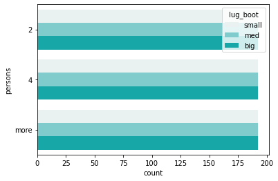

```python
sns.countplot(y="persons", data = data , color="c", hue="lug_boot")
```

## Normalization

In this step we will transfrom our categorical data into dummy variables, we don't need to change the scale for these dummy variables since they are already between 0 and 1

## Splitting the data into a train and test set

```python
from sklearn.preprocessing import LabelEncoder
country = LabelEncoder()

#data['buying'] = country.fit_transform(data['persons'])
#data['main'] = country.fit_transform(data['persons'])
#data['persons'] = country.fit_transform(data['persons'])
#data['safety'] = country.fit_transform(data['persons'])
#data['lug_boot'] = country.fit_transform(data['persons'])

x = data.drop(columns = ['acceptability','doors','Y'])
print(x.head())
x = pd.get_dummies(x, drop_first=True)
y = data['Y']

print(x)

from sklearn.model_selection import train_test_split
X_train, X_test, y_train, y_test = train_test_split(x, y, test_size=0.3, random_state=0)
```

```
  buying   main persons lug_boot safety
0  vhigh  vhigh       2    small    low
1  vhigh  vhigh       2    small    med
2  vhigh  vhigh       2    small   high
3  vhigh  vhigh       2      med    low
4  vhigh  vhigh       2      med    med
      buying_low  buying_med  buying_vhigh  main_low  main_med  main_vhigh  \
0              0           0             1         0         0           1
1              0           0             1         0         0           1
2              0           0             1         0         0           1
3              0           0             1         0         0           1
4              0           0             1         0         0           1
...          ...         ...           ...       ...       ...         ...
1723           1           0             0         1         0           0
1724           1           0             0         1         0           0
```

[output cut: 31 more lines]

## Decision trees

The decision trees algorithm will do a wrapper(built-in) model for feature selection , that's why we will build our tree using all features as input but we will specify that the tree has a maximum depth of 3, which means that it will choose the top 3 features

```python
from sklearn.tree import DecisionTreeClassifier


tree_model = DecisionTreeClassifier(criterion='entropy', max_depth=3, random_state=0)
tree_model.fit(X_train, y_train)

from sklearn import metrics

y_pred_train=tree_model.predict(X_train)
accuracy_train=metrics.accuracy_score(y_train, y_pred_train)

print("Accuracy train: {0:.1f}%".format(accuracy_train* 100))

#Predict the response of the dataset

y_pred=tree_model.predict(X_test)
accuracy=metrics.accuracy_score(y_test, y_pred)
print("Accuracy is {0:.1f}%".format(accuracy*100))
```

```
Accuracy train: 87.4%
Accuracy is 85.0%
```

```python
param_grid = {"criterion": ["gini", "entropy"],
             "min_samples_split": [10, 20, 40],
             "max_depth": [3,4,5],
             "min_samples_leaf": [1,20, 40, 100],
             "max_leaf_nodes": [5,10,20]}

grid = GridSearchCV(tree_model, param_grid,cv=10)
search=grid.fit(X_train, y_train)
y_predgrid=grid.predict(X_test)

print("Accuracy train: {0:.1f}%".format(search.best_score_ * 100))
print("Best Hyperparameters::\n{}".format(search.best_params_))

print("Accuracy test score: {0:.1f}%".format(accuracy_score(y_test,y_predgrid)* 100))
import pydotplus
from pydotplus import graph_from_dot_data
from sklearn.tree import export_graphviz
print("Classification report  \n %s" %(classification_report(y_test, y_predgrid)))
```

```
Accuracy train: 90.5%
Best Hyperparameters::
{'criterion': 'gini', 'max_depth': 5, 'max_leaf_nodes': 20, 'min_samples_leaf': 1, 'min_samples_split': 10}
Accuracy test score: 88.4%
Classification report
               precision    recall  f1-score   support

          No       0.77      0.87      0.82       156
         Yes       0.94      0.89      0.92       363

    accuracy                           0.88       519
   macro avg       0.86      0.88      0.87       519
weighted avg       0.89      0.88      0.89       519
```

```python
#print(acc_train)
```

```python
import pydotplus
from pydotplus import graph_from_dot_data
from sklearn.tree import export_graphviz
import os


os.environ['PATH'] = os.environ['PATH']+';'+os.environ['CONDA_PREFIX']+r"\Library\bin\graphviz"

import graphviz
!set PATH=PATH;C:\path\to\anaconda\Library\bin\graphviz\

tree_model = DecisionTreeClassifier(criterion='gini', max_depth = 6, max_leaf_nodes=5,
                                    min_samples_leaf=1,min_samples_split= 20,random_state=0)

tree_model.fit(X_train, y_train)

#Visualizing the tree
from sklearn import tree

from IPython.display import display, Image
#Image(filename='tree_model.png', width=600)
import pydotplus
from pydotplus import graph_from_dot_data
from sklearn.tree import export_graphviz

import os

os.environ['PATH'] = os.environ['PATH']+';'+os.environ['CONDA_PREFIX']+r"\Library\bin\graphviz"

!set PATH=PATH;C:\Users\computer\Anaconda3\Library\bin\graphviz

dot_data = export_graphviz(tree_model,
                           filled=True,
                           rounded=False,
                           class_names = ['Yes','No'],
                           feature_names=X_train.columns,
                           out_file=None)
graph = graph_from_dot_data(dot_data)
graph.write_png('churntree.png')
```

```
True
```

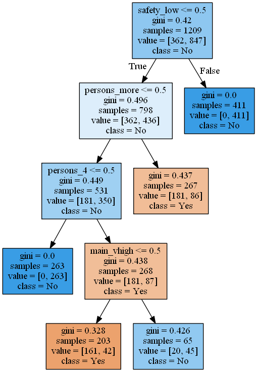

```python
Image(filename='churntree.png', width=1000)
```

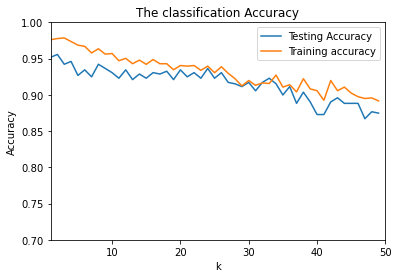

```python
X_train, X_test, y_train, y_test = train_test_split(x, y, test_size=0.3, random_state=1)

acc_test = np.empty(50)
acc_train = np.empty(50)
num_neighbors=np.empty(50)

#Building the knn model for values of k between 1 and 100 and choosing the value that gives the best accuracy score for the test set
for i in range(1, 50):
    classifier = KNeighborsClassifier(n_neighbors = i)
    classifier.fit(X_train, y_train)
    y_train_pred = classifier.predict(X_train)
    y_test_pred  = classifier.predict(X_test)

    acc_train[i]=metrics.accuracy_score(y_train,y_train_pred)
    acc_test[i]=metrics.accuracy_score(y_test_pred, y_test)
    num_neighbors[i]=i

plt.title('The classification Accuracy')
plt.plot(num_neighbors, acc_test, label='Testing Accuracy')
plt.plot(num_neighbors, acc_train, label='Training accuracy')
plt.xlabel('k')
plt.ylabel('Accuracy')
plt.legend()
plt.ylim(0.7, 1)
plt.xlim(1, 50)
plt.show()
```

```python
classifier = KNeighborsClassifier(n_neighbors = 25)
classifier.fit(X_train, y_train)
y_train_pred = classifier.predict(X_train)
y_test_pred  = classifier.predict(X_test)
acc_train=metrics.accuracy_score(y_train,y_train_pred)
acc_test=metrics.accuracy_score(y_test,y_test_pred)

print(acc_train)
print(acc_test)
print("Classification report  \n %s" %(classification_report(y_test, y_test_pred)))
```

```
0.9305210918114144
0.9229287090558767
Classification report
               precision    recall  f1-score   support

          No       0.91      0.82      0.86       151
         Yes       0.93      0.96      0.95       368

    accuracy                           0.92       519
   macro avg       0.92      0.89      0.90       519
weighted avg       0.92      0.92      0.92       519
```

```python
classifier = BaggingClassifier()
classifier.fit(X_train, y_train)
y_train_pred = classifier.predict(X_train)
y_test_pred  = classifier.predict(X_test)
acc_train=metrics.accuracy_score(y_train,y_train_pred)
acc_test=metrics.accuracy_score(y_test,y_test_pred)

print(acc_train)
print(acc_test)
print("Classification report  \n %s" %(classification_report(y_test, y_test_pred)))
```

```
0.9801488833746899
0.9614643545279383
Classification report
               precision    recall  f1-score   support

          No       0.92      0.95      0.93       151
         Yes       0.98      0.97      0.97       368

    accuracy                           0.96       519
   macro avg       0.95      0.96      0.95       519
weighted avg       0.96      0.96      0.96       519
```

We remark that the evalutation metrics are better using the bagging classifier and that totally makes sense becuase we are aggregating the decisions of many classifiers (the same algorithm trained on different samples of data with replacement), each of which has an accuracy > 0.5 and they are independant of each other.

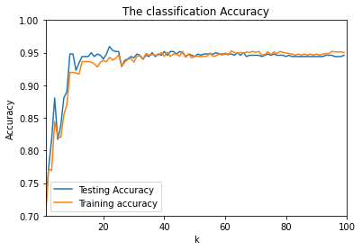

```python
acc_train = []
acc_test= []
est = []

for i in range(1,100):
          clf = AdaBoostClassifier(n_estimators = i)
          clf.fit(X_train, y_train)
          y_pred_train = clf.predict(X_train)
          acc_train.append(metrics.accuracy_score(y_train, y_pred_train))

         # print("Accuracy train: {0:.1f}%".format(accuracy_train* 100))

#Predict the response of the dataset

          y_pred=clf.predict(X_test)
          acc_test.append(metrics.accuracy_score(y_test, y_pred))
         # print("Accuracy test is {0:.1f}%".format(accuracy*100))
          est.append(i)
          #print("Classification report  \n %s" %(classification_report(y_test, y_pred)))

plt.title('The classification Accuracy')
plt.plot(est, acc_test, label='Testing Accuracy')
plt.plot(est, acc_train, label='Training accuracy')
plt.xlabel('k')
plt.ylabel('Accuracy')
plt.legend()
plt.ylim(0.7, 1)
plt.xlim(1, 100)
plt.show()
```

As the number of estimators increases the accuracy improves, up to 96% for about 23 estimators

```python
classifier = AdaBoostClassifier(n_estimators = 22)
classifier.fit(X_train, y_train)
y_train_pred = classifier.predict(X_train)
y_test_pred  = classifier.predict(X_test)
acc_train=metrics.accuracy_score(y_train,y_train_pred)
acc_test=metrics.accuracy_score(y_test,y_test_pred)

print("Training accuracy {0:.1f}%".format(acc_train*100))
print("Testing accuracy {0:.1f}%".format(acc_test*100))
print("Classification report  \n %s" %(classification_report(y_test, y_test_pred)))
```

```
Training accuracy 94.3%
Testing accuracy 96.0%
Classification report
               precision    recall  f1-score   support

          No       0.92      0.94      0.93       151
         Yes       0.98      0.97      0.97       368

    accuracy                           0.96       519
   macro avg       0.95      0.95      0.95       519
weighted avg       0.96      0.96      0.96       519
```

We remark that the evalutation metrics are better using the bagging classifier and adaboost (96% for both) with impressive recall, precision, f1_scores for both class lavels and both classifiers (all above 90%) and this totally makes sense becuase we are aggregating the decisions of many classifiers (the same algorithm trained on different samples of data with replacement), each of which has an accuracy > 0.5 and they are independant of each other.